# Car Selling Prices

Dawn Galloway

1/20/2023

[figure not shown]

## Selling Price of a Ford Explorer

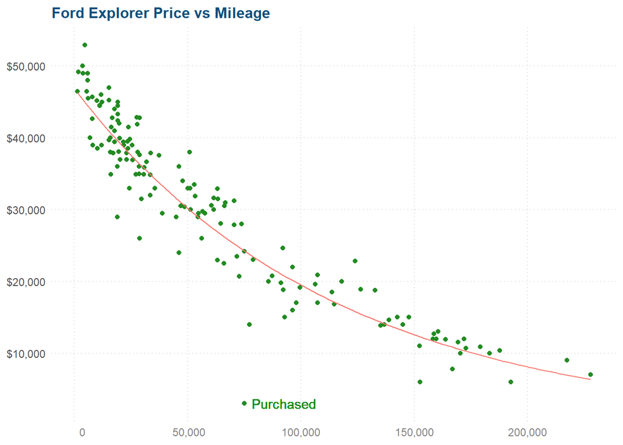

```r
library(tidyverse)
library(ggplot2)
library(DT)
library(car)
library(pander)
car_dat <- read.csv("CarPricesTrue.csv")

# aesthetics
palette(c("#ffc6c6", "#eeaa88", "#eec290", "grey", "#afc9c6", "#468499"))

my_theme <- theme(legend.position = "none", panel.background = element_blank(), plot.background = element_blank(),
    panel.grid.major.y = element_line(color = "grey88", linetype = "dotted"), panel.grid.major.x = element_line(color = "grey88",
        linetype = "dotted"), plot.title = element_text(color = "#0C4F7B", size = 12,
        face = "bold"), plot.caption = element_text(color = "gray50", face = "italic",
        size = 6, hjust = 0.5), axis.ticks = element_blank(), axis.title = element_blank(),
    axis.text.x = element_text(color = "gray50"))

# regression values
lm.log <- lm(log(price) ~ mileage, data = car_dat)
b.log <- coef(lm.log)

# plotted regression
car_plot <- ggplot(car_dat, aes(y = price, x = mileage)) + geom_point(color = "forestgreen",
    pch = 16) + geom_text(x = 92500, y = 3000, label = "Purchased", color = "forestgreen") +
    labs(title = "Ford Explorer Price vs Mileage", x = "Mileage", y = "Price (USD)") +
    scale_y_continuous(labels = scales::dollar_format()) + scale_x_continuous(labels = function(x) format(x,
    big.mark = ",")) + my_theme

car_plot + stat_function(fun = function(x) exp(b.log[1] + b.log[2] * x), aes(color = "log(Y)"))
```

Clearly, re-selling the Ford Explorer immediately after purchase would have been the best decision. * I still need to add the sale point and a line segment with explanation. *

## Technical Details

### Linear Regression

We fit a linear regression model to the car data.

$$\underbrace{Y_i}_\text{Price} = \overbrace{\beta_0}^\text{y-int} + \overbrace{\beta_1}^\text{slope} \underbrace{X_i}_\text{Mileage} + \epsilon_i \quad \text{where} \ \epsilon_i \sim N(0, \sigma^2)$$

#### Hypothesis

The null hypothesis for the analysis is that the slope is zero; there is not a linear relationship between the mileage and the price of Ford Explorers. The alternative hypothesis is that slope is not zero; there is in a linear relationship between the mileage and the price. The level of significance for our purposes is 0.05.

$$H_0: \beta_1 = 0$$

$$H_a: \beta_1 \neq 0$$

$$\alpha = 0.05$$

#### Regression Plot

We plot a linear regression on the price versus mileage.

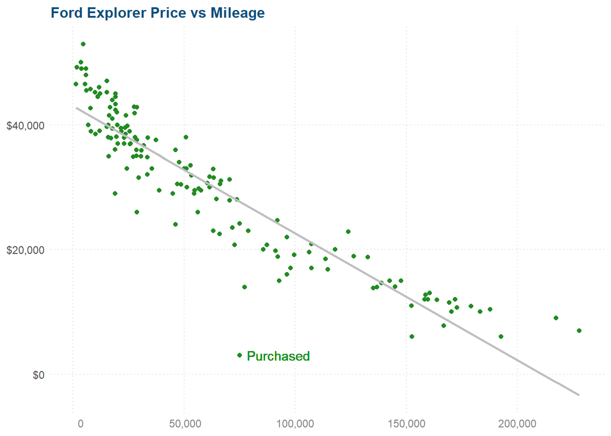

#### Regression Results

Below is a summary of the results.

```r
# regression summary
pander(car.sum <- summary(car.lm))
```

|  | Estimate | Std. Error | t value | Pr(>\|t\|) |
| --- | --- | --- | --- | --- |
| **(Intercept)** | 42975 | 570.7 | 75.3 | 3.067e-122 |
| **mileage** | -0.2036 | 0.006855 | -29.7 | 3.578e-65 |

Fitting linear model: price ~ mileage

| Observations | Residual Std. Error | $R^2$ | Adjusted $R^2$ |
| --- | --- | --- | --- |
| 154 | 4648 | 0.853 | 0.8521 |

$$\underbrace{\hat{Y}_i}_\text{Mean Price} = \overbrace{ \$ 42,975.18}^\text{est. y-int} - \overbrace{0.20 }^\text{est. slope}* \underbrace{X_i}_\text{Mileage}$$

#### Regression Assumptions

We examine the assumptions.

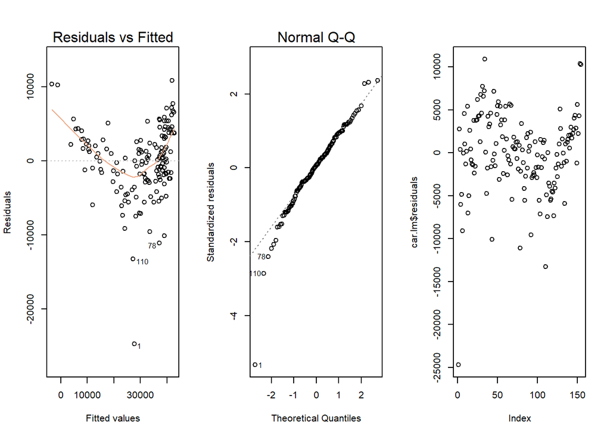

```r
par(mfrow = c(1, 3))
plot(car.lm, which = 1:2)
plot(car.lm$residuals)

#### BOXCOX RUN TO SEE WHAT IT SAYS
```

The residuals vs fitted plot shows issues with both the linearity and the variance, while the residuals vs Order indicates there may be issues with the independence of the error terms.

### Y Transformations

We will compare different transformations to see whether we can improve the outcome.

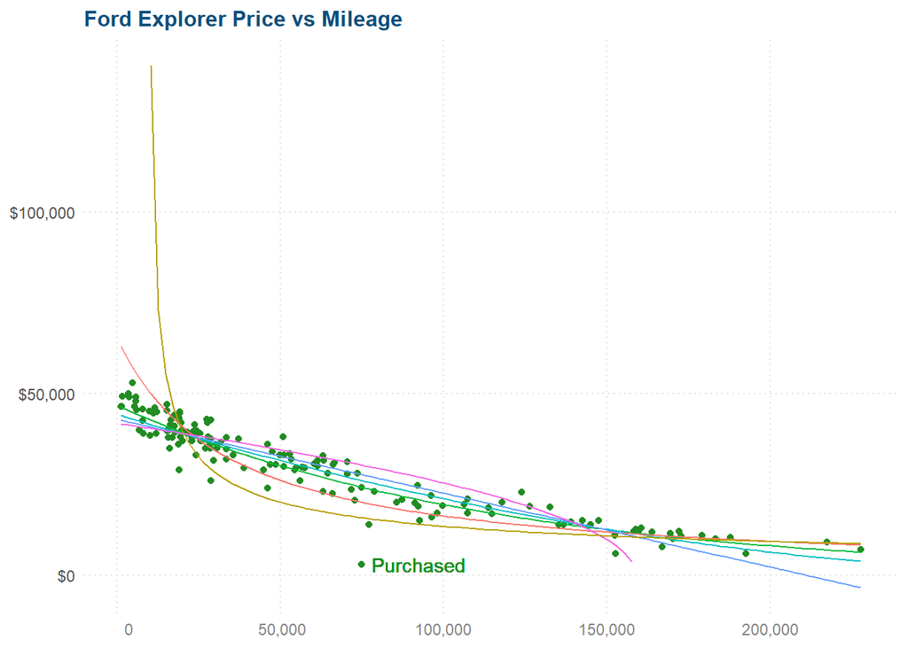

```r
# lm.log <- lm(log(price) ~ mileage, data=car_dat) b.log <- coef(lm.log)

lm.sqrt <- lm(sqrt(price) ~ mileage, data = car_dat)
b.sqrt <- coef(lm.sqrt)

lm.1oY <- lm(1/(price) ~ mileage, data = car_dat)
b.1oY <- coef(lm.1oY)


b.y <- coef(car.lm)

lm.y2 <- lm((price^2) ~ mileage, data = car_dat)
b.y2 <- coef(lm.y2)

lm.1oY2 <- lm(1/(price^2) ~ mileage, data = car_dat)
b.1oY2 <- coef(lm.1oY2)


# transformations plot
car_plot + stat_function(fun = function(x) exp(b.log[1] + b.log[2] * x), aes(color = "log(Y)")) +
    stat_function(fun = function(x) (b.sqrt[1] + b.sqrt[2] * x)^2, aes(color = "sqrt(Y)")) +
    stat_function(fun = function(x) 1/(b.1oY[1] + b.1oY[2] * x), aes(color = "1/Y")) +
    stat_function(fun = function(x) b.y[1] + b.y[2] * x, aes(color = "Y")) + stat_function(fun = function(x) sqrt(b.y2[1] +
    b.y2[2] * x), aes(color = "Y^2")) + stat_function(fun = function(x) 1/sqrt(b.1oY2[1] +
    b.1oY2[2] * x), aes(color = "1/Y^2"))


# ggplot(car_dat, aes(x=mileage, y=price)) + geom_point(color='forestgreen') +
# geom_text(x=92500, y=3000, label = 'Purchased', color='forestgreen') +
# stat_function(fun=function(x) exp(b.log[1] + b.log[2]*x),
# aes(color='log(Y)')) + stat_function(fun=function(x) (b.sqrt[1] +
# b.sqrt[2]*x)^2, aes(color='sqrt(Y)')) + stat_function(fun=function(x)
# 1/(b.1oY[1] + b.1oY[2]*x), aes(color='1/Y')) + stat_function(fun=function(x)
# b.y[1] + b.y[2]*x, aes(color='Y')) + stat_function(fun=function(x)
# sqrt(b.y2[1] + b.y2[2]*x), aes(color='Y^2')) + stat_function(fun=function(x)
# 1/sqrt(b.1oY2[1] + b.1oY2[2]*x), aes(color='1/Y^2')) + labs(title='Ford
# Explorer Price vs Mileage', x='Mileage', y='Price (USD)') + theme_minimal() +
# scale_y_continuous(labels = scales::dollar_format()) +
# scale_x_continuous(labels = function(x) format(x, big.mark = ',')) + my_theme

# predict(mylm, data.frame(Barometer=30.35)) par(mfrow=c(1,3)) plot(mylm, which
# = 1:2) plot(mylm$residuals)


# plot(Price ~ Mileage, data=SedanPrices, col=Model, main='Relationship Between
# Price and Mileage', pch=16, ylab='Price in U.S. Dollars') abline(a=
# sedansSim.lm$coefficients[1], b=sedansSim.lm$coefficients[2],
# col=palette()[2])
# abline(a=sedansSim.lm$coefficients[1]+sedansSim.lm$coefficients[3],
# b=sedansSim.lm$coefficients[2], col=palette()[1]) legend('topright',
# col=palette(), pch=16, legend=c('Chevy Malibu', 'Chevy Corolla'), bty='n',
# text.col = palette()) par(mfrow=c(1,3)) plot(sedansSim.lm, which=1,
# caption=NA) mtext(side=3, text='Residuals vs Fitted')
# qqPlot(sedansSim.lm$residuals) mtext(side=3,text='Residuals QQ Plot')
# plot(sedansSim.lm$residuals) mtext(side=3, text='Residuals vs Order')
```

#### BoxCox

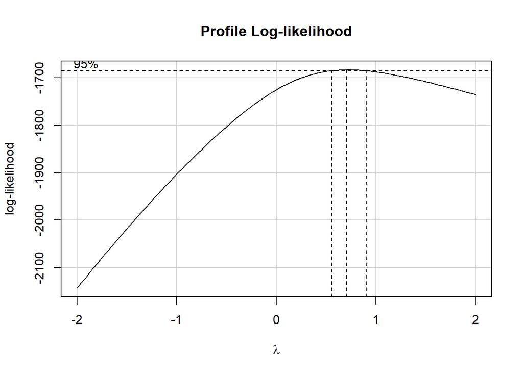

```r
boxCox(lm(price ~ mileage, data = car_dat))
```

When we run the Box Cox test, the center line suggests a $\lambda$ of 0.75. However, this isn’t easily intepretable, so we will examine $\lambda$ values of 0.5 and 0.

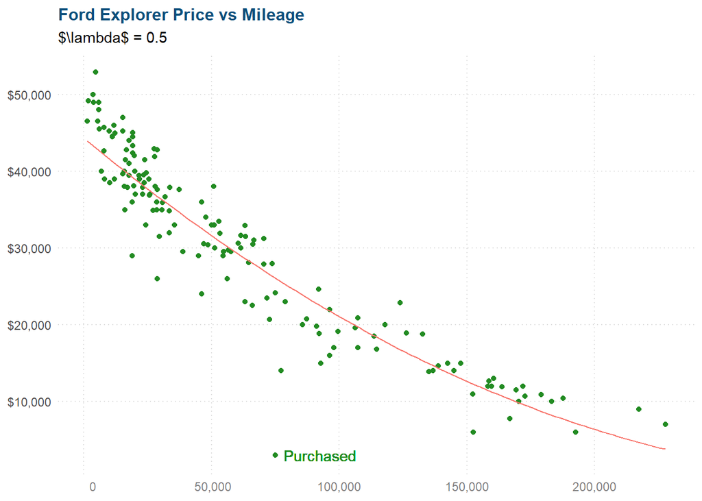

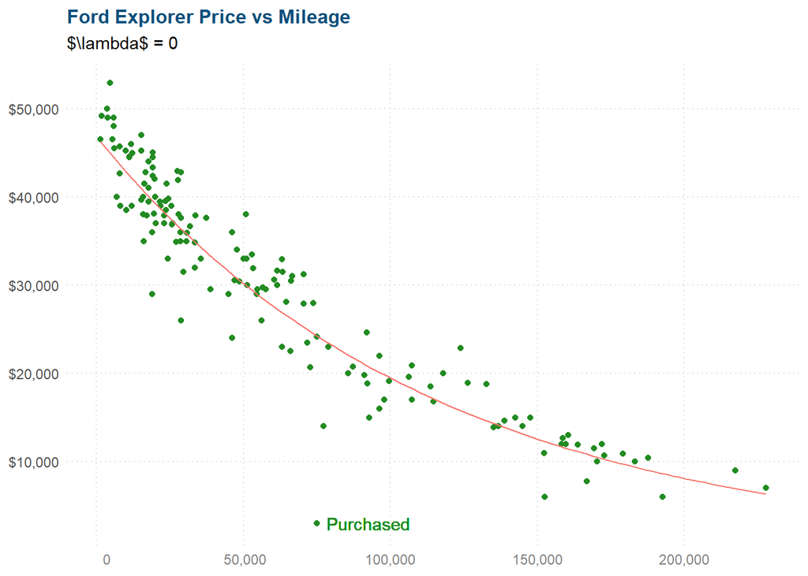

```r
car_plot + stat_function(fun = function(x) (b.sqrt[1] + b.sqrt[2] * x)^2, aes(color = "sqrt(Y)")) +
    labs(subtitle = "$\\lambda$ = 0.5")

car_plot + stat_function(fun = function(x) exp(b.log[1] + b.log[2] * x), aes(color = "log(Y)")) +
    labs(subtitle = "$\\lambda$ = 0")
```

Eventhough, the square root transformation version was closer to the Box Cox value selected by the function, the log version looks like it fits the data slightly better.

#### Assumptions

The assumptions for the log transformation plot (below, right three) look better, as the square root plot is having more difficulty with linearity.

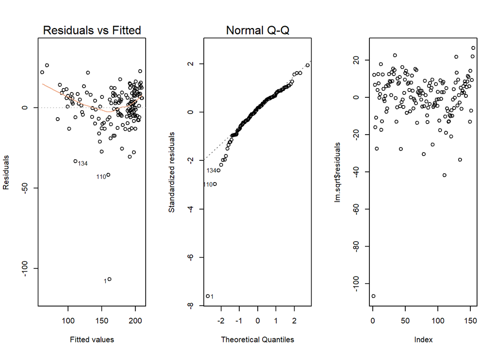

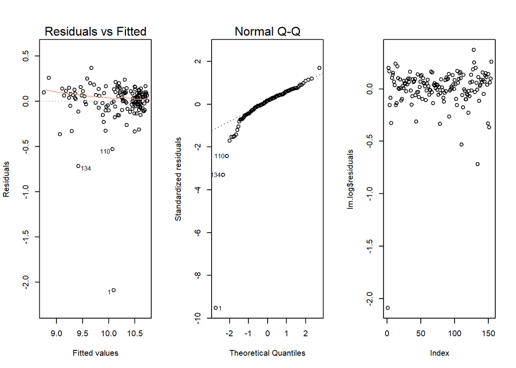

```r
par(mfrow = c(1, 3))
plot(lm.sqrt, which = 1:2)
plot(lm.sqrt$residuals)

par(mfrow = c(1, 3))
plot(lm.log, which = 1:2)
plot(lm.log$residuals)
```